# TRIP FEATURE ANALYSIS

## By Akolade Sofiyyah Iwalewa

## Investigation Overview

> The investigation emphasizes on the frequency, duration and length of trips. Important features are:
> - Trip lenght
> - Trip duration
> - Dates (start and end times)
> - Start and end stations
> - Gender
> - Age group and
> - User types.

## Dataset Overview

> The ford gobike system dataset includes information about individual rides made in a bike-sharing system covering the greater San Francisco Bay area. It contains 16 columns and 183412 rows which became 25 columns and 174952 rows after cleaning and feature engineering. This projects explores the periods and how often the bike rides/trips are made in the area.

## Peak times of trip starts and ends over 24 hours.

> Most Users start their trips by 8AM in the morning, and end it by 5PM in the evening. This is one of the expected insight to the data because majority of the Users are most probably white or blue collar workers, or students who set out for work and close around those peak times.

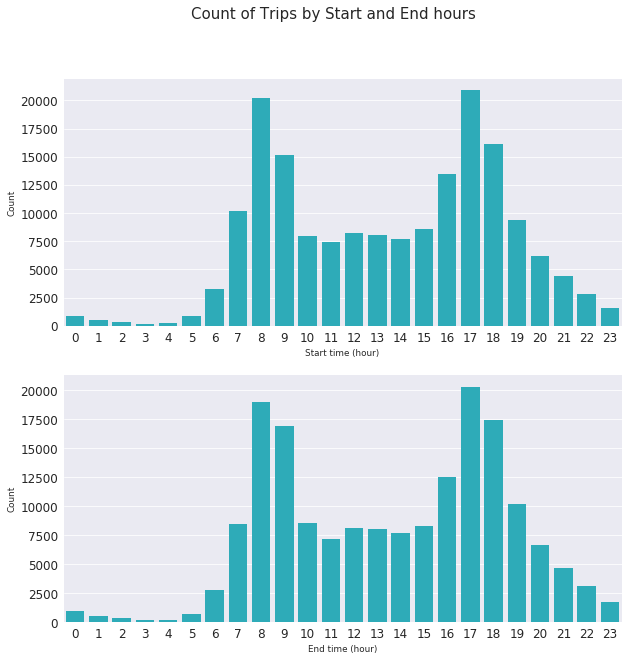

## Trend of trips across the month

> The users mostly use the bike on work days especially Monday, Tuesday, Thursday and Friday. There is a slight decrease on Wednessday compare to other week days. The use of bike is low on weekends which implies that users do no usually go out on weekends.

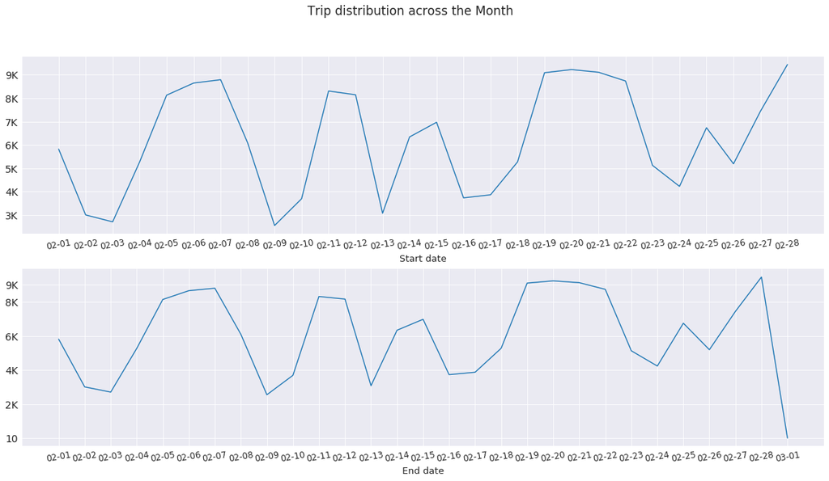

## How did those dates affect trips by User type?

> For both days, the relative amount of Subscribers that did not take bike trips are more than that of the Customers. This proves that Customers takes businesses seriously than Subscribers.

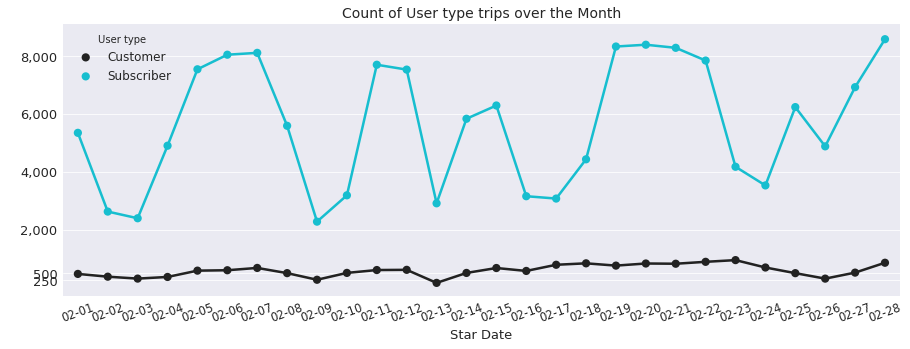

## Average distance ravelled by Users by demographics

> On average, Females travel longer distances compared to males, wih age group 30-40 averaging the most distance travelled by age group. Also, Customers take longer distances compared to Subscribers who are way more than Customers.

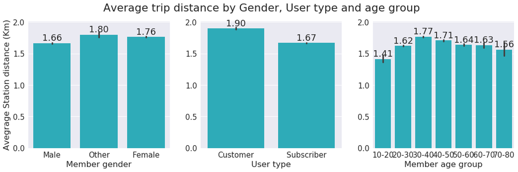

## Average time, in hours, trips by Users by demographics.

> The Gender "Other" significantly spend more time on the road compared to Males and Females. Customers stay longer with the bikes, because on average they spend more time on trips han Subscribers. Across age groups, the average time spent on trips is roughly the same; 0.19 - 0.23 hours.

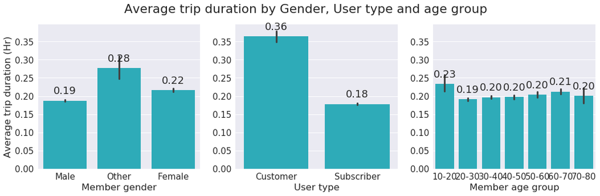

## What are the most used docking stations?

Majority of the most used docking staions are around Market Sreet.

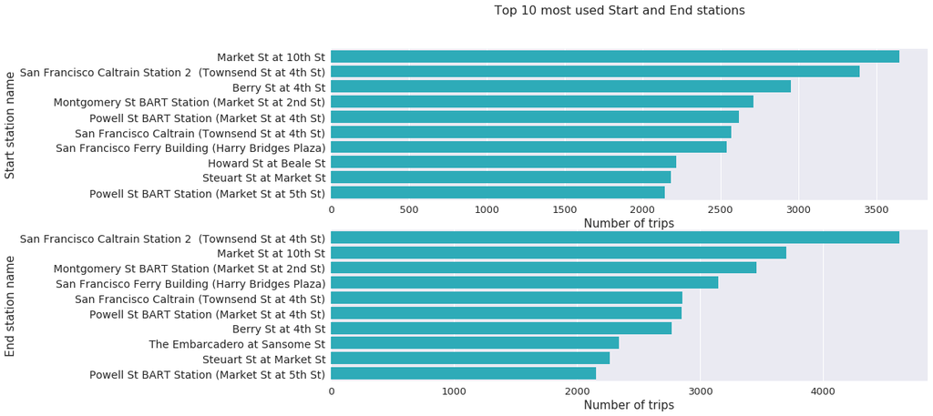